# Lab 1

Parker Davis

2023-01-22

# Tasks

## Task 1

Working directory is:

```r
getwd()
```

```
## [1] "C:/RPACKAGES/FALL224753davi0607/MATH 4753 Labs/Lab1"
```

## Task 2

First six lines of the DDT.csv is

```r
ddt <- read.csv("DDT-1.csv")
head(ddt,6)
```

```
##   RIVER MILE  SPECIES LENGTH WEIGHT DDT
## 1   FCM    5 CCATFISH   42.5    732  10
## 2   FCM    5 CCATFISH   44.0    795  16
## 3   FCM    5 CCATFISH   41.5    547  23
## 4   FCM    5 CCATFISH   39.0    465  21
## 5   FCM    5 CCATFISH   50.5   1252  50
## 6   FCM    5 CCATFISH   52.0   1255 150
```

## Task 3

Qualitative Variables in the DDT data set: River, Species

Quantitative Variables in the DDT data set: Mile, Length, Weight, DDT  
Number of species in DDT Data set: 3

```r
summary.data.frame(ddt)
```

```
##     RIVER                MILE         SPECIES              LENGTH
##  Length:144         Min.   :  1.0   Length:144         Min.   :17.50
##  Class :character   1st Qu.:283.8   Class :character   1st Qu.:40.50
##  Mode  :character   Median :300.0   Mode  :character   Median :45.00
##                     Mean   :268.6                      Mean   :42.81
##                     3rd Qu.:320.0                      3rd Qu.:47.50
##                     Max.   :345.0                      Max.   :52.00
##      WEIGHT            DDT
##  Min.   : 173.0   Min.   :   0.110
##  1st Qu.: 805.5   1st Qu.:   3.375
##  Median :1000.0   Median :   7.150
##  Mean   :1049.7   Mean   :  24.355
##  3rd Qu.:1257.8   3rd Qu.:  13.000
##  Max.   :2302.0   Max.   :1100.000
```

This is the subset of the ddt data with only observations with SPECIES being LMBASS and WEIGHT bigger than 800 grams

```r
big800 = with(ddt, ddt[WEIGHT > 800 & SPECIES == "LMBASS",])

summary(big800)
```

```
##     RIVER                MILE       SPECIES              LENGTH
##  Length:2           Min.   :345   Length:2           Min.   :30.0
##  Class :character   1st Qu.:345   Class :character   1st Qu.:31.5
##  Mode  :character   Median :345   Mode  :character   Median :33.0
##                     Mean   :345                      Mean   :33.0
##                     3rd Qu.:345                      3rd Qu.:34.5
##                     Max.   :345                      Max.   :36.0
##      WEIGHT          DDT
##  Min.   : 856   Min.   :1.900
##  1st Qu.:1000   1st Qu.:1.975
##  Median :1144   Median :2.050
##  Mean   :1144   Mean   :2.050
##  3rd Qu.:1289   3rd Qu.:2.125
##  Max.   :1433   Max.   :2.200
```

This is the subset of the ddt data with only observations where the RIVER is SCM and DDT is greater than 4.0

```r
rvSCM = with(ddt, ddt[RIVER == "SCM"& DDT > 4.0,])

summary(rvSCM)
```

```
##     RIVER                MILE     SPECIES              LENGTH
##  Length:3           Min.   :1   Length:3           Min.   :43.00
##  Class :character   1st Qu.:1   Class :character   1st Qu.:44.00
##  Mode  :character   Median :1   Mode  :character   Median :45.00
##                     Mean   :1                      Mean   :44.33
##                     3rd Qu.:1                      3rd Qu.:45.00
##                     Max.   :1                      Max.   :45.00
##      WEIGHT            DDT
##  Min.   : 965.0   Min.   :4.10
##  1st Qu.: 974.5   1st Qu.:5.95
##  Median : 984.0   Median :7.80
##  Mean   :1011.0   Mean   :7.00
##  3rd Qu.:1034.0   3rd Qu.:8.45
##  Max.   :1084.0   Max.   :9.10
```

## Clicker Questions

Using these data sets and subsets above, we can see that the mean length of the fish in the ddt data frame is:

```r
attach(ddt)
mean(LENGTH)
```

```
## [1] 42.8125
```

The standard deviation for weight of fish in the ddt data set is:

```r
attach(ddt)
sd(WEIGHT)
```

```
## [1] 376.5461
```

Here is the ACTUAL plot of Length vs. Weight, the one in the lab manual is actually incorrect, due to the names of the axes being wrong.

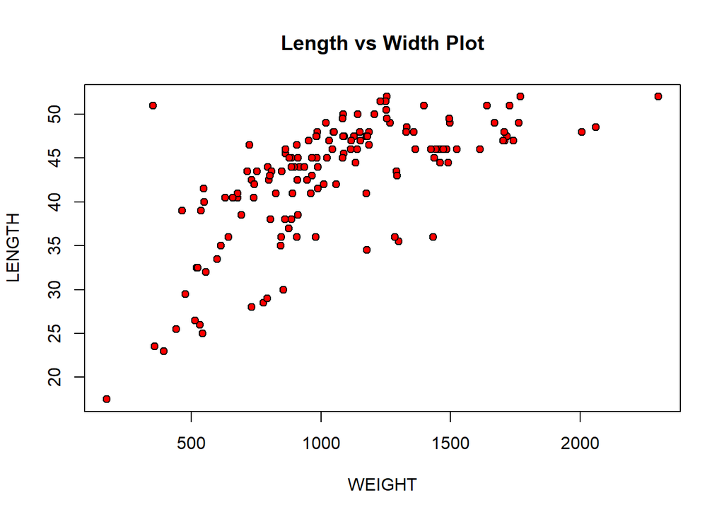

```r
with(ddt,plot(x = WEIGHT, y = LENGTH, pch=21, bg = "Red", main = "Length vs Width Plot"))
```

## Task 4

Table and barplot of Rivers:

```r
rv=with(ddt,table(RIVER))
rv
```

```
## RIVER
## FCM LCM SCM TRM
##   6   6   6 126
```

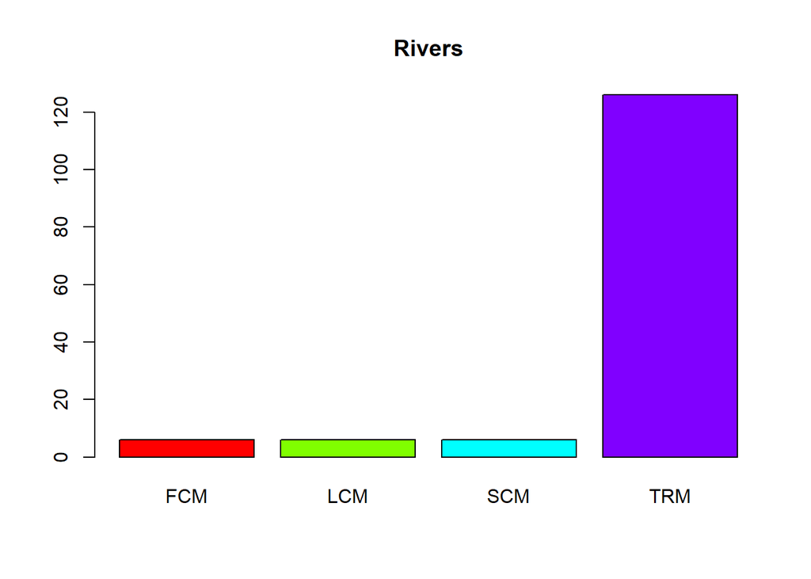

```r
barplot(rv, beside = TRUE, col = rainbow(4), main = "Rivers")
```

Table and barplot of Rivers crossed with Species of Fish:

```r
rvspc=with(ddt,table(RIVER,SPECIES))
rvspc
```

```
##      SPECIES
## RIVER CCATFISH LMBASS SMBUFFALO
##   FCM        6      0         0
##   LCM        6      0         0
##   SCM        6      0         0
##   TRM       78     12        36
```

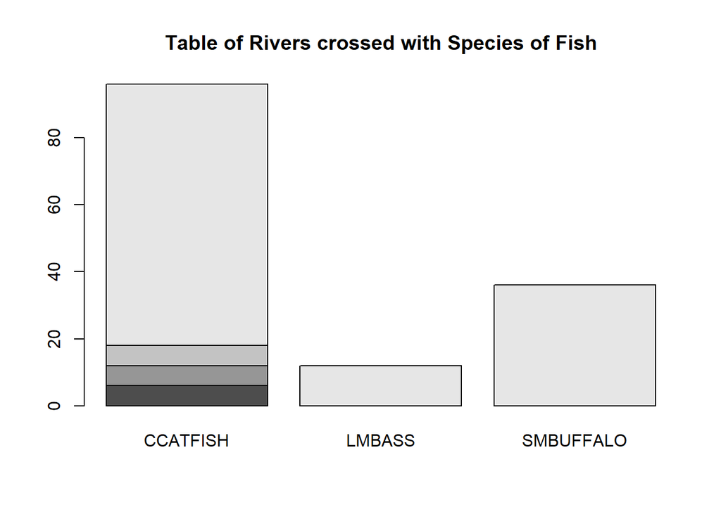

```r
barplot(rvspc, main = "Table of Rivers crossed with Species of Fish")
```

## Task 5

Pie Charts of Fish Species and Rivers

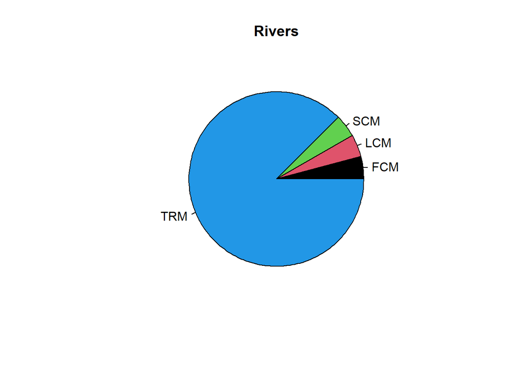

```r
pie(rv, col = 1:4, main = "Rivers")
```

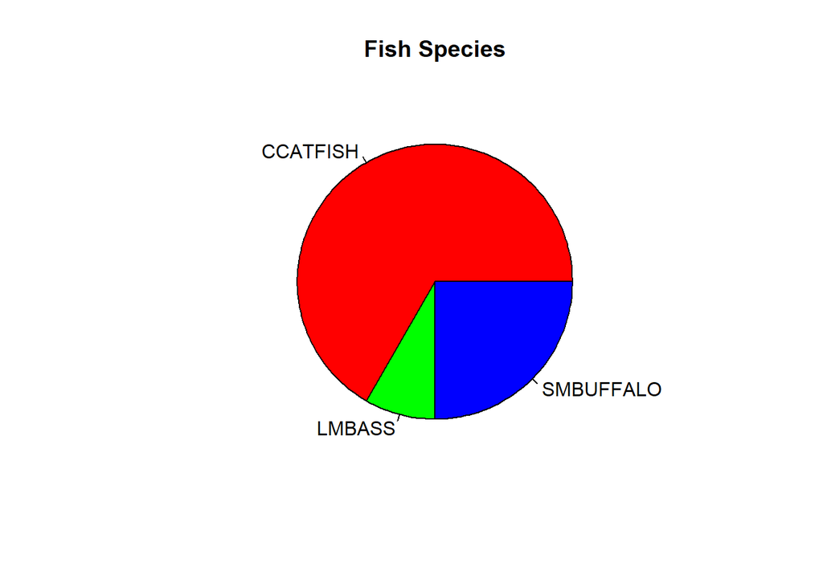

```r
spc=with(ddt,table(SPECIES))
pie(spc, col = rainbow(3), main = "Fish Species")
```

## Task 6

These are the boxplots for several variables

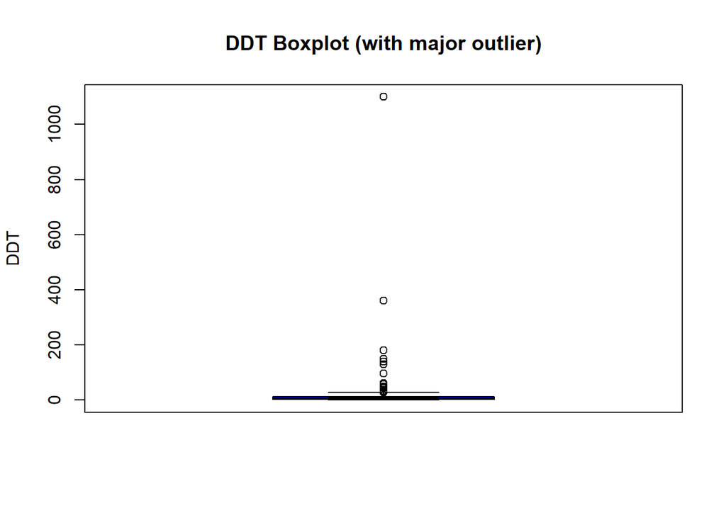

```r
with(ddt,boxplot(DDT,ylab = "DDT", col = "Blue", notch = TRUE, main= "DDT Boxplot (with major outlier)"))
```

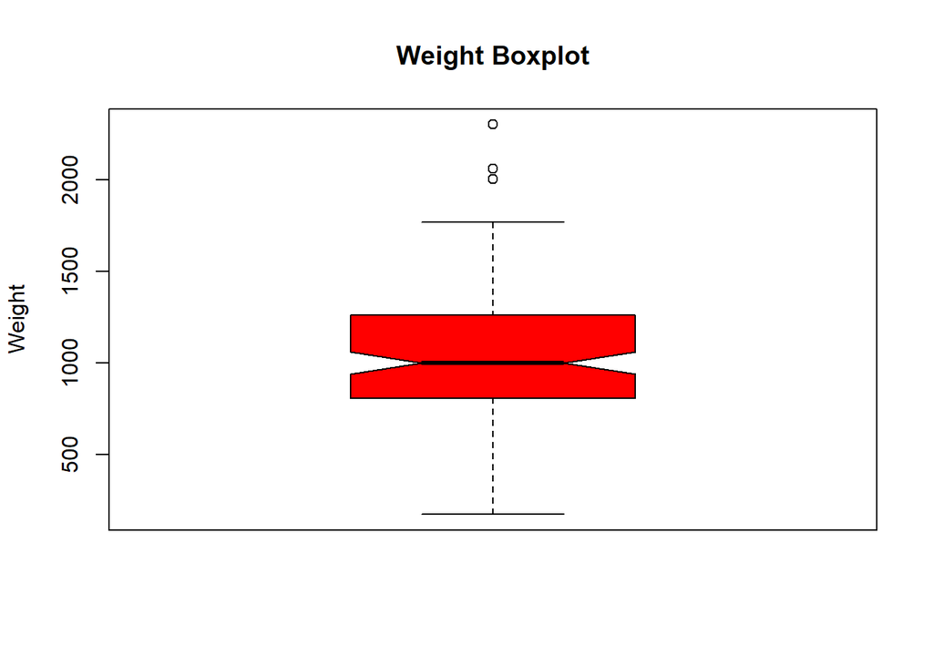

```r
with(ddt,boxplot(WEIGHT,ylab="Weight",col="Red",notch=TRUE,main="Weight Boxplot"))
```

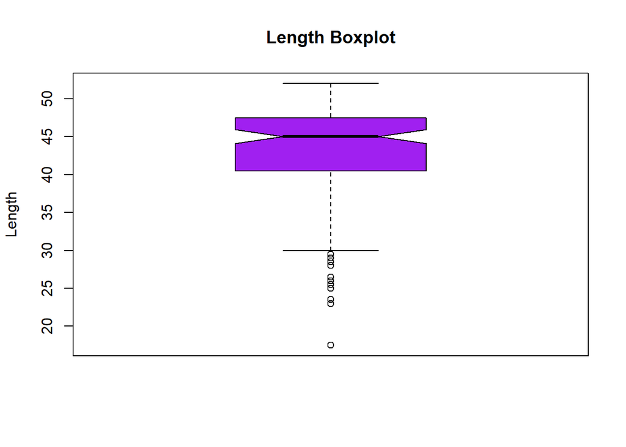

```r
with(ddt, boxplot(LENGTH,ylab="Length",col="Purple",notch = TRUE,main="Length Boxplot"))
```